Statistical Learning · Binary Classification

# Logistic Regression: Predicting Stock Market Direction

Applying logistic regression to classify daily S&P 500 market movements as Up or Down using lagged return and trading volume features from the Smarket dataset.

R tidymodels Logistic Regression Classification 5-Fold CV

## 01Mathematical Foundation

Logistic regression models the probability of a binary outcome by transforming a linear predictor through the logistic (sigmoid) function:

p(X) = e<sup>β₀ + β₁X</sup> / (1 + e<sup>β₀ + β₁X</sup>)

Rearranging to express the log-odds (logit) form:

log( p(X) / (1 − p(X)) ) = β₀ + β₁X

This transformation ensures predicted probabilities remain in [0, 1] while allowing the relationship between predictors and log-odds to be linear—a key property that makes the model both interpretable and tractable to fit via maximum likelihood.

**Odds interpretation example:** An individual with a 23% chance of defaulting has odds of default = 0.23 / 0.77 ≈ 0.30. For every ~3 non-defaults, there is 1 default event.

## 02Dataset: S&P 500 Daily Returns

The **Smarket** dataset from the ISLR package contains 1,250 daily observations of S&P 500 percentage returns from 2001–2005. The classification target is `Direction`—whether the market closed Up or Down on each trading day.

```
glimpse(Smarket)
```

Rows: 1,250 | Columns: 9 Variables: Year, Lag1, Lag2, Lag3, Lag4, Lag5, Volume, Today, Direction Direction levels: "Down" (reference), "Up" (positive class)

### Variable Correlations

The pairwise correlation structure of all variables was examined using `ggpairs()` from the GGally package. This provides simultaneous views of distributions (diagonal), scatter plots (lower triangle), and Pearson correlation coefficients (upper triangle).

```
library(GGally)
ggpairs(Smarket,
        lower = list(combo = wrap(ggally_facethist, binwidth = 0.5)),
        progress = FALSE)
```

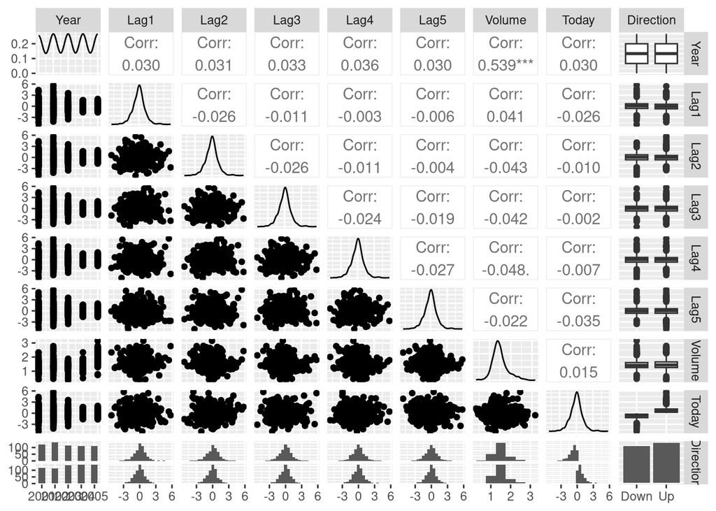

Figure 1. Pairwise relationships in the Smarket dataset. The highest correlation (0.539) is between Year and Volume, indicating trading volume increased over time. Lag variables show near-zero correlations with each other and with Direction.

The most striking finding from this visualization is that the Lag variables (Lag1–Lag5) and Volume show very weak correlations with the outcome variable Direction and with each other. The only strong correlation in the dataset is between **Year and Volume (r = 0.539)**, suggesting a secular upward trend in trading volume over the 2001–2005 period—but this relationship has no direct bearing on predicting market direction.

## 03Logistic Regression: Full Model (Lag1–Lag5 + Volume)

A logistic regression model was fit using all five lagged returns and Volume as predictors. Coefficients, p-values, and 95% confidence intervals were extracted for inference.

```
logit_fit <- logistic_reg() |>
  set_engine("glm") |>
  fit(Direction ~ Lag1 + Lag2 + Lag3 + Lag4 + Lag5 + Volume,
      data = Smarket)

logit_fit |> tidy(conf.int = TRUE)
```

| Predictor | Estimate | Std. Error | Statistic | p-value | 95% CI |
| --- | --- | --- | --- | --- | --- |
| (Intercept) | −0.126 | 0.241 | −0.523 | 0.601 | [−0.599, 0.345] |
| **Lag1** | **−0.0731** | 0.0502 | −1.46 | **0.145** | [−0.172, 0.025] |
| Lag2 | −0.0423 | 0.0501 | −0.845 | 0.398 | [−0.141, 0.056] |
| Lag3 | 0.0111 | 0.0499 | 0.222 | 0.824 | [−0.087, 0.109] |
| Lag4 | 0.00936 | 0.0500 | 0.187 | 0.851 | [−0.089, 0.107] |
| Lag5 | 0.0103 | 0.0495 | 0.208 | 0.835 | [−0.087, 0.108] |
| Volume | 0.135 | 0.158 | 0.855 | 0.392 | [−0.174, 0.447] |

**Lag1** has the smallest p-value (0.145), though it does not reach the conventional α = 0.05 threshold. Its negative coefficient (−0.0731) indicates that a one-unit increase in the previous day's return is associated with a decrease of 0.0731 in the log-odds of the market moving Up. However, the 95% CI [−0.172, 0.025] contains zero, so we cannot reject the null hypothesis that Lag1 has no effect on Direction.

### Exponentiated Coefficients (Odds Ratios)

```
logit_fit |> tidy(exponentiate = TRUE)
```

| Predictor | Odds Ratio | Interpretation |
| --- | --- | --- |
| Lag1 | 0.930 | Each +1 unit in Lag1 decreases odds of "Up" by ~7% |
| Lag2 | 0.959 | Each +1 unit in Lag2 decreases odds of "Up" by ~4% |
| Volume | 1.15 | Higher volume slightly increases odds of "Up" |

## 04Predictive Performance via 5-Fold CV

To evaluate predictive accuracy rather than just inferential associations, 5-fold cross-validation was applied to both the full model (Lag1–Lag5 + Volume) and a reduced model (Lag1 + Lag2 only).

```
set.seed(132)
market_cv <- vfold_cv(Smarket, v = 5)

logit_workflow <- workflow() |>
  add_model(logistic_reg() |> set_engine("glm")) |>
  add_recipe(recipe(Direction ~ Lag1 + Lag2 + Lag3 + Lag4 + Lag5 + Volume,
                    data = Smarket))

logit_res <- fit_resamples(logit_workflow, resamples = market_cv)
collect_metrics(logit_res)
```

| Model | Predictors | CV Accuracy | ROC-AUC |
| --- | --- | --- | --- |
| Full model | Lag1–Lag5 + Volume | 0.501 | 0.502 |
| Reduced model | Lag1 + Lag2 | 0.510 | 0.514 |

### Summary & Conclusions

Logistic regression was used to investigate whether lagged returns and trading volume predict S&P 500 daily direction. Despite a rigorous inferential and predictive framework, the analysis finds that these features have essentially no predictive power for market direction.

The preferred model—Lag1 + Lag2—is the simpler specification, consistent with the principle that when predictive performance is comparable, the model with fewer parameters is preferred. The simplicity reduces the risk of spurious relationships and is more interpretable, even when both models perform poorly.

This result is consistent with the efficient market hypothesis: if past price information were reliably predictive of future movements, arbitrage would eliminate the pattern. The near-random accuracy of these models supports the view that daily S&P 500 returns are largely unpredictable from the features examined here.